# Reproducible Research Project 1

2025-09-06

# Overview

This report follows the exact tasks of **Reproducible Research (Project 1)** in the Coursera Data Science Specialization (JHU). It uses the activity monitoring dataset with steps recorded every 5 minutes.

**Variables** - `steps`: number of steps in a 5-minute interval (may be `NA`) - `date`: measurement date (YYYY-MM-DD) - `interval`: the 5-minute interval identifier (e.g. 0, 5, 10, …, 2355)

> Reproducibility: all code chunks are self-contained. If `activity.csv` is missing, the script attempts to download and unzip it automatically.

# Data: Load and Preprocess

## Obtain the dataset (download if needed)

```r
zip_url  <- "https://d396qusza40orc.cloudfront.net/repdata%2Fdata%2Factivity.zip"
zip_file <- "activity.zip"
csv_file <- "activity.csv"

# If the CSV isn't present, try to download and unzip it
if (!file.exists(csv_file)) {
  if (!file.exists(zip_file)) {
    message("Downloading dataset…")
    try(download.file(zip_url, destfile = zip_file, mode = "wb"), silent = TRUE)
  }
  if (file.exists(zip_file)) {
    unzip(zip_file)
  } else {
    warning("Could not download dataset automatically. Please place 'activity.csv' in the working directory.")
  }
}
```

## Read and inspect

```r
activity <- readr::read_csv(
  csv_file,
  show_col_types = FALSE,
  progress = FALSE,
  col_types = cols(
    steps    = col_double(),
    date     = col_date(),    # parse to Date
    interval = col_integer()
  )
)

glimpse(activity)
```

```
## Rows: 17,568
## Columns: 3
## $ steps    <dbl> NA, NA, NA, NA, NA, NA, NA, NA, NA, NA, NA, NA, NA, NA, NA, N…
## $ date     <date> 2012-10-01, 2012-10-01, 2012-10-01, 2012-10-01, 2012-10-01, …
## $ interval <int> 0, 5, 10, 15, 20, 25, 30, 35, 40, 45, 50, 55, 100, 105, 110, …
```

> **Note:** We will treat `NA` values as *missing measurements*, not zeros. The first analysis excludes missing values, and a later section imputes them.

# 1. Mean total number of steps taken per day

**Statistical goal:** Compute the distribution of the *daily total* number of steps, then report its **mean** and **median**.

Mathematically, for each day $d$, the total steps $T_d = \sum_i s_{di}$ where $s_{di}$ are the 5-minute-interval step counts observed that day (ignoring missing entries).

```r
daily_steps <- activity %>%
  group_by(date) %>%
  summarise(total_steps = sum(steps, na.rm = TRUE), .groups = "drop")

mean_steps   <- mean(daily_steps$total_steps, na.rm = TRUE)
median_steps <- median(daily_steps$total_steps, na.rm = TRUE)

# Show summary statistics
tribble(
  ~Statistic, ~Value,
  "Mean of total steps/day (original)",   mean_steps,
  "Median of total steps/day (original)", median_steps
)
```

```
## # A tibble: 2 × 2
##   Statistic                             Value
##   <chr>                                 <dbl>
## 1 Mean of total steps/day (original)    9354.
## 2 Median of total steps/day (original) 10395
```

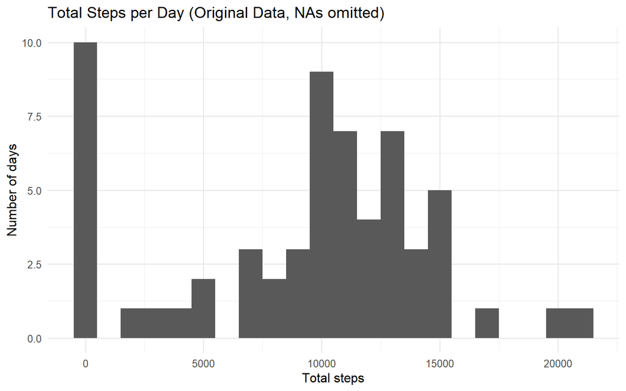

```r
# Histogram of daily totals
ggplot(daily_steps, aes(x = total_steps)) +
  geom_histogram(binwidth = 1000) +
  labs(title = "Total Steps per Day (Original Data, NAs omitted)",
       x = "Total steps", y = "Number of days") +
  theme_minimal(base_size = 12)
```

**Interpretation tips:** - The mean gives the *central tendency* of daily totals. - The median is robust to outliers; if mean ≫ median, distribution might be right-skewed.

# 2. Average daily activity pattern

**Goal:** For each 5-minute `interval`, compute the **average steps across all days** and identify the interval with the highest average.

Formally, for interval $j$, $\bar{s}_j = \nolinebreak \frac{1}{|D_j|} \sum_{d \in D_j} s_{dj}$, averaging across days where the interval was observed.

```r
interval_means <- activity %>%
  group_by(interval) %>%
  summarise(mean_steps = mean(steps, na.rm = TRUE), .groups = "drop")

peak_interval <- interval_means %>% slice_max(mean_steps, n = 1)
peak_interval
```

```
## # A tibble: 1 × 2
##   interval mean_steps
##      <int>      <dbl>
## 1      835       206.
```

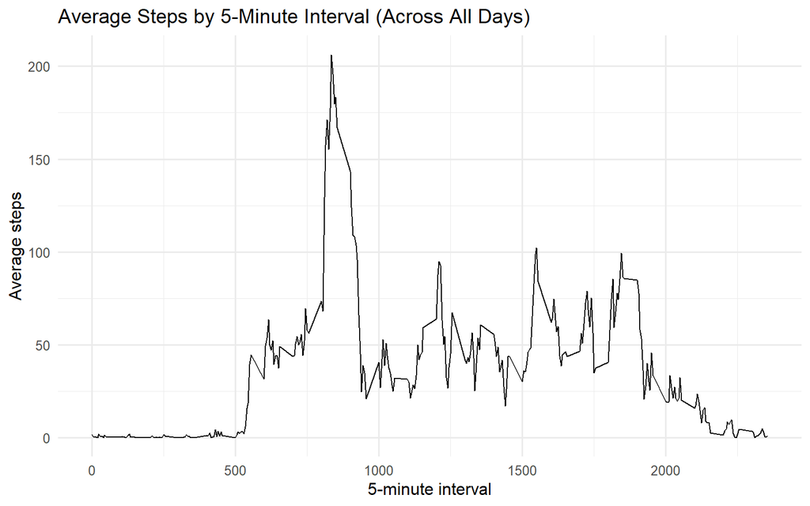

```r
# Time-series of the mean steps by interval
ggplot(interval_means, aes(x = interval, y = mean_steps)) +
  geom_line() +
  labs(title = "Average Steps by 5-Minute Interval (Across All Days)",
       x = "5-minute interval", y = "Average steps") +
  theme_minimal(base_size = 12)
```

**Interpretation tip:** The peak interval often corresponds to morning activity spikes.

# 3. Imputing missing values

**Goal:** Quantify missingness, then create a complete dataset by imputing `NA` values. We use a simple, assignment-aligned strategy: *replace missing `steps` with the average for that 5-minute `interval` across all days*.

```r
# Total number of missing step values
total_na <- sum(is.na(activity$steps))
tribble(~Metric, ~Value, "Total NA values in 'steps'", total_na)
```

```
## # A tibble: 1 × 2
##   Metric                     Value
##   <chr>                      <int>
## 1 Total NA values in 'steps'  2304
```

```r
# Impute NAs using the interval means (do NOT round to preserve averages)
activity_imputed <- activity %>%
  left_join(interval_means, by = "interval") %>%
  mutate(steps = if_else(is.na(steps), mean_steps, steps)) %>%
  select(steps, date, interval)

# Recompute daily totals with imputed data
daily_steps_imputed <- activity_imputed %>%
  group_by(date) %>%
  summarise(total_steps = sum(steps), .groups = "drop")

mean_steps_imp   <- mean(daily_steps_imputed$total_steps)
median_steps_imp <- median(daily_steps_imputed$total_steps)

tribble(
  ~Statistic, ~Value,
  "Mean of total steps/day (imputed)",   mean_steps_imp,
  "Median of total steps/day (imputed)", median_steps_imp
)
```

```
## # A tibble: 2 × 2
##   Statistic                            Value
##   <chr>                                <dbl>
## 1 Mean of total steps/day (imputed)   10766.
## 2 Median of total steps/day (imputed) 10766.
```

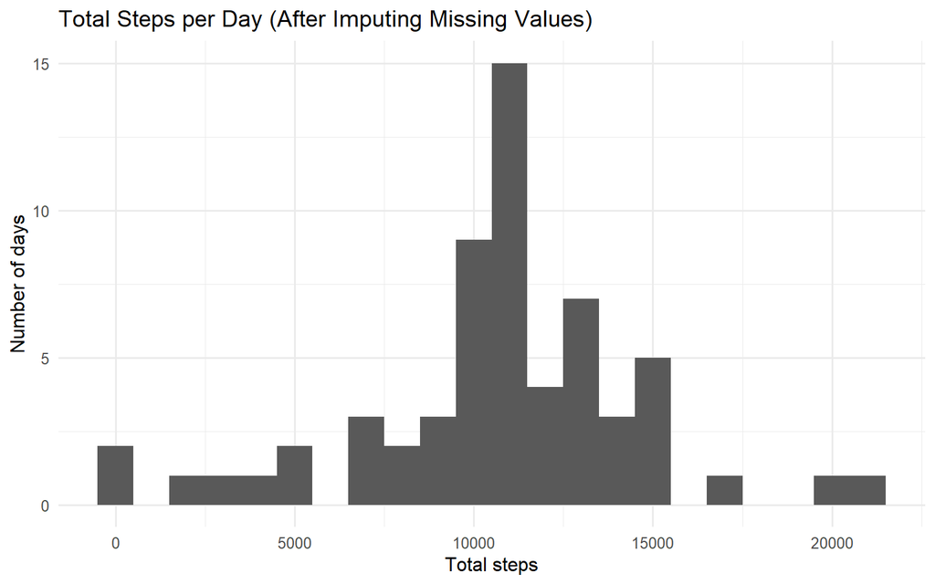

```r
# Histogram after imputation
ggplot(daily_steps_imputed, aes(x = total_steps)) +
  geom_histogram(binwidth = 1000) +
  labs(title = "Total Steps per Day (After Imputing Missing Values)",
       x = "Total steps", y = "Number of days") +
  theme_minimal(base_size = 12)
```

**Compare original vs imputed**

```r
comparison <- tibble(
Metric = c("Mean (original)", "Median (original)", "Mean (imputed)", "Median (imputed)"),
Value  = c(mean_steps, median_steps, mean_steps_imp, median_steps_imp)
)
comparison
```

```
## # A tibble: 4 × 2
##   Metric             Value
##   <chr>              <dbl>
## 1 Mean (original)    9354.
## 2 Median (original) 10395
## 3 Mean (imputed)    10766.
## 4 Median (imputed)  10766.
```